# STAT 490 Network Models and Simulations

## Simulating an Infectious Disease

### Load R libraries

```r
library(rmarkdown)
library(knitr)
library(igraph)
```

### Import data

```r
vs <- read.csv("https://www.dropbox.com/s/jof7z88aqbsj0ho/e.csv?dl=1")
es <- read.csv("https://www.dropbox.com/s/zyakaii9vr0al11/e.csv?dl=1")
G <- graph.data.frame(es, vs, directed = T)
UG <- as.undirected(G)
```

## Simulating a Blood Parasite (Unvaccinated Population)

### Exercise 1:

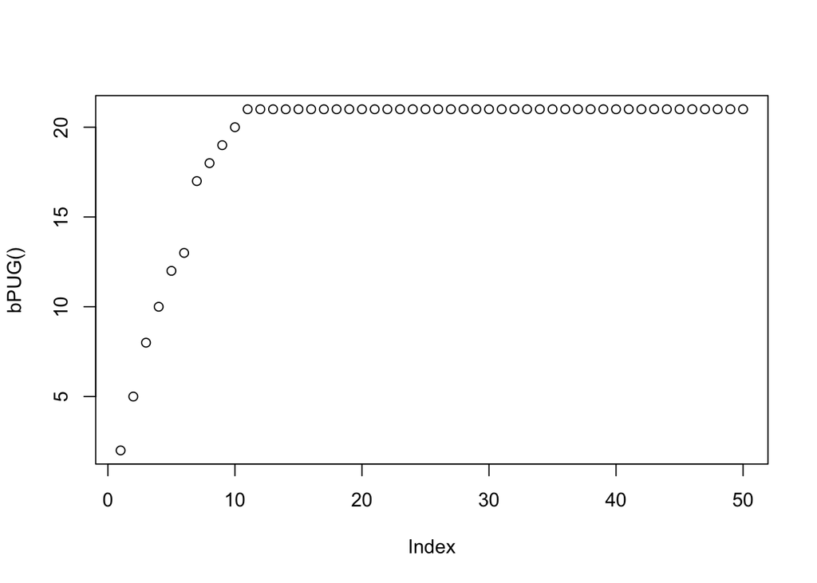

```r
NUG <- UG
bPUG <- function()
{
  V(NUG)$state <<- 0
  V(NUG)$color <<- "green"
  random <- sample(1:21, size =1)
  V(NUG)$state[random] <<- 1
  V(NUG)$color[random] <<- "red"
  UG <<- NUG
  infectedCount <- c()
  for( i in (1:50))
  {
    V(NUG)$state[intersect(unlist(adjacent_vertices(NUG, which(V(NUG)$state == 1))),  which(V(NUG)$state == 0))] <<-rbinom(length(intersect(unlist(adjacent_vertices(NUG, which(V(NUG)$state == 1))),  which(V(NUG)$state == 0))),1,.413)
    V(NUG)$color[V(NUG)$state == 1] <<-"red"
    infectedCount[i] <- sum(V(NUG)$state == 1)
  }
  return(infectedCount)
}
plot(bPUG())
```

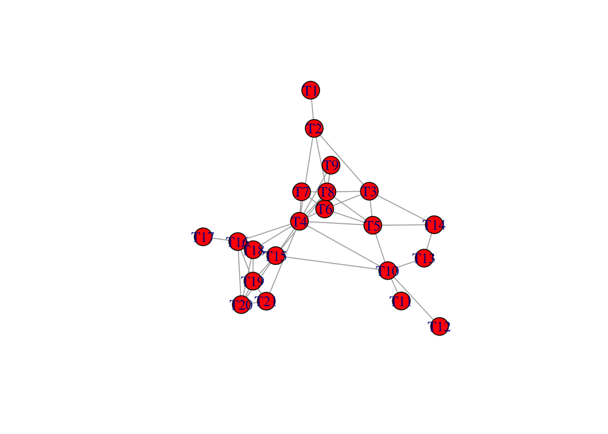

```r
plot(NUG)
```

### Exercise 2:

Visualize the spatial distribution of susceptible and infected tuatara at the start and end of a single trial of this Blood Parasite.

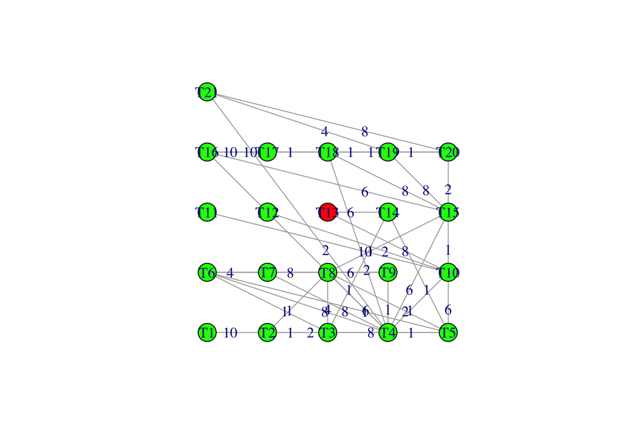

```r
plot(UG, layout = layout.grid(UG), edge.label=E(UG)$weight)
```

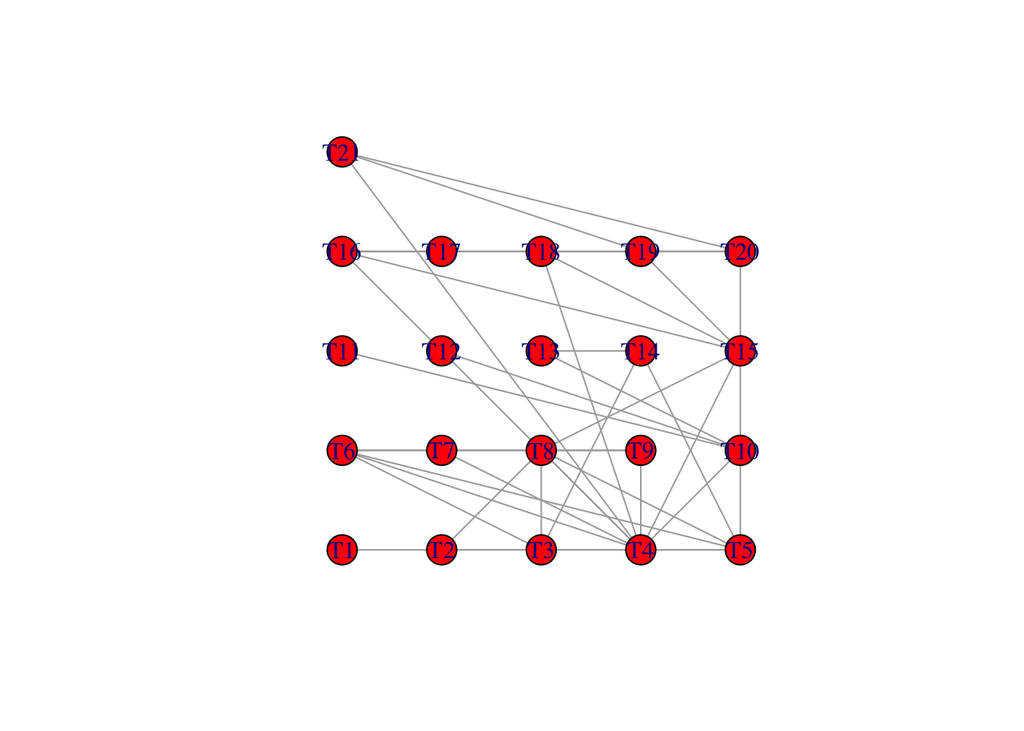

```r
plot(NUG, layout = layout.grid(NUG))
```

### Exercise 3:

Calculate the average and standard deviation of the duration of the outbreak (i.e., the number of time steps before all tuatara were infected) across 1000 trials of this Blood Parasite.

```r
bPUG <- function()
{
  V(NUG)$state <<- 0
  V(NUG)$color <<- "green"
  random <- sample(1:21, size =1)
  V(NUG)$state[random] <<- 1
  V(NUG)$color[random] <<- "red"
  UG <<- NUG
  infectedCount <- c()
  i<- 1
  for( i in (1:50))
  {
    V(NUG)$state[intersect(unlist(adjacent_vertices(NUG, which(V(NUG)$state == 1))),  which(V(NUG)$state == 0))] <<-rbinom(length(intersect(unlist(adjacent_vertices(NUG, which(V(NUG)$state == 1))),  which(V(NUG)$state == 0))),1,.413)
    V(NUG)$color[V(NUG)$state == 1] <<-"red"
    infectedCount[i] <- sum(V(NUG)$state == 1)
    if(infectedCount[i] == 21)
    {
      return(i)
    }
  }
  #return(i)
  return(i)
}
count <- replicate(100,bPUG())
mean(count)
```

```
## [1] 10.65
```

```r
sd(count)
```

```
## [1] 2.889811
```

### Exercise 4:

Discuss any patterns you observe in exercise (3).

[output not shown]

### Exercise 5:

Write a function to simulate the blood parasite based on an undirected but weighted version of the tuatara network.

```r
bPUG <- function()
{
  V(NUG)$state <- 0
  V(NUG)$color <- "green"
  random <- sample(1:21, size =1)
  V(NUG)$state[random] <- 1
  V(NUG)$color[random] <- "red"
  UG <<- NUG
  infectedCount <- c()
  i <- 1
  count <- 0
  result <- 0
 while(i <= 50 & result < 21)
 {
   for(j in (1:21))
   {
     for(k in(1:21))
     {
       if(are.connected(NUG, j, k))
       {
         if(V(NUG)[j]$state == 1 && V(NUG)[k]$state == 0)
         {
           p <- 0.1 * E(NUG,c(j,k))$weight
           V(NUG)[k]$state <- rbinom(1,1,p)
         }
       }
     }
   }
   result <- sum(V(NUG)$state == 1)
   count <- i
   i<- i+1
  }
  return(count)
}
```

### Exercise 6:

Calculate the average and standard deviation of the duration of the outbreak across 1000 trials of this Blood Parasite.

```r
count <- replicate(100,(bPUG()))
mean(count)
```

```
## [1] 9.64
```

```r
sd(count)
```

```
## [1] 5.755138
```

### Exercise 7:

Write a function to simulate the blood parasite based on a directed and weighted version of the tuatara network.

```r
NG <- G
bPG <- function()
{
  V(NG)$state <- 0
  V(NG)$color <- "green"
  random <- sample(1:21, size =1)
  V(NG)$state[random] <- 1
  V(NG)$color[random] <- "red"
  G <<- NG
  infectedCount <- c()
  i <- 1
  count <- 0
  result <- 0
 while(i <= 50 & result < 21)
 {
   for(j in (1:21))
   {
     for(k in(1:21))
     {
       if(are.connected(NG, j, k))
       {
         if(V(NG)[j]$state == 1 && V(NG)[k]$state == 0)
         {
           p <- 0.1 * E(NUG,c(j,k))$weight
           V(NG)[k]$state <- rbinom(1,1,p)
         }
       }
     }
   }
   result <- sum(V(NG)$state == 1)
   count <- i
   i<- i+1
 }
    return(count)

}
```

### Exercise 8:

Calculate the average and standard deviation of the duration of the outbreak across 1000 trials of this Blood Parasite.

```r
count <- replicate(100,(bPG()))
mean(count)
```

```
## [1] 48.33
```

```r
sd(count)
```

```
## [1] 7.349919
```

### Exercise 9:

Discuss what effect incorporating contact heterogeneity has on how quickly a blood parasite spreads through a population. Justify your answer numerically.

[output not shown]

### Exercise 10:

Discuss what effect incorporating contact directionality has on how quickly a blood parasite spreads through a population. Justify your answer numerically.

[output not shown]

## Simulating a Blood Parasite (Vaccinated Population)

### Exercise 11:

Write a function that takes the names of three vertices as arguments, vaccinates them, simulates the spread of a blood parasite over 50 time steps across the remaining 18 vertices based on a directed and weighted version of the tuatara network, and returns the number of infected individuals at each step.

```r
es <- read.csv("https://www.dropbox.com/s/zyakaii9vr0al11/e.csv?dl=1")
G <- graph.data.frame(es, vs, directed = T)
NG <- G
bPG <- function(ran, rand, rando)
{
  V(G)$color[ran] <<- "yellow"
  V(G)$color[rand] <<- "yellow"
  V(G)$color[rando] <<- "yellow"

  V(NG)$state <<- 0
  V(NG)$color <<- "green"

  V(NG)$state[ran] <<- 2
  V(NG)$state[rand] <<- 2
  V(NG)$state[rando] <<- 2

  random <- sample((1:21), size = 1)
  while( !ran == random && !rand == random && !rando == random)
  {
    random <- sample((1:21), size = 1)
  }
   V(NG)$state[random] <<- 1
   V(NG)$color[random] <<- "red"
   G <<- NG
   V(G)$color[V(G)$state == 1] <<- "red"
  V(G)$color[V(G)$state == 0] <<- "green"
  infectedCount <- c()

  for( i in (1:50))
  {
   for(j in (1:21))
   {
     for(k in(1:21))
     {
       if(are.connected(NG, j, k))
       {
         if(V(NG)[j]$state == 1 && V(NG)[k]$state == 0)
         {
           p <- 0.1 * E(NUG,c(j,k))$weight
           V(NG)[k]$state <<- rbinom(1,1,p)
         }
       }
     }
       }

   infectedCount[i] <- sum(V(NG)$state == 1)
  }
  V(NG)$color[V(NG)$state == 1] <<- "red"
    V(NG)$color[V(NG)$state == 0] <<- "green"

  return(infectedCount)

}
```

### Exercise 12:

Visualize the spatial distribution of susceptible, infected, and vaccinated tuatara at the start and end of a single trial of this Blood Parasite, using three random vertices as arguments (i.e., vaccinate three tuatara at random).

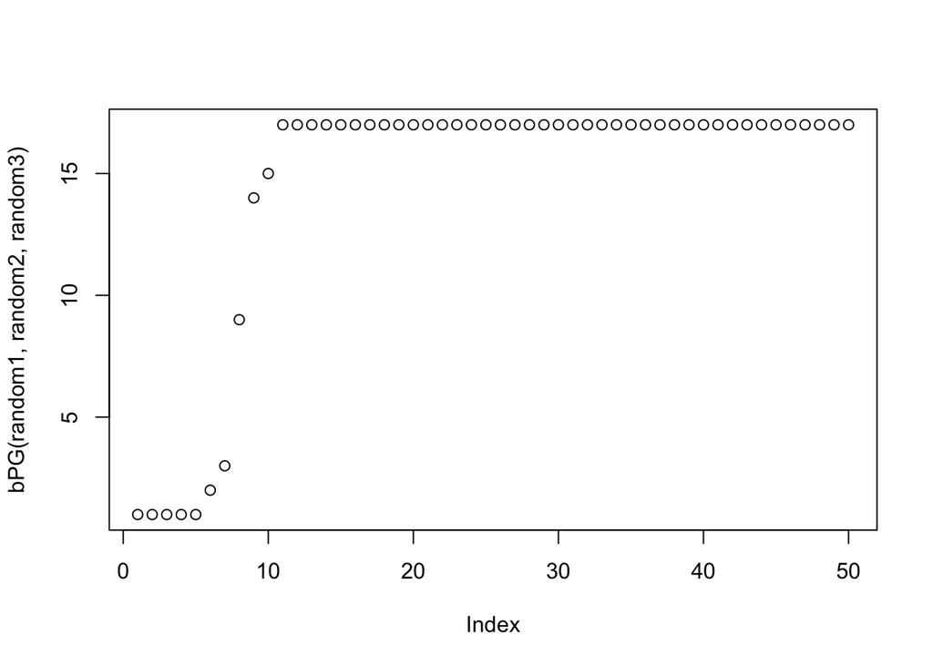

```r
list <- c(1:21)
random1 <- sample(x=list, size =1)
list1 <- list[list != random1]
random2 <- sample(x=list1, size = 1)
list2 <- list1[list1 != random2]
random3 <- sample(x=list2, size = 1)
list3 <- list2[list2 != random3]
#bPG(random1, random2, random3)
plot(bPG( random1, random2, random3))
```

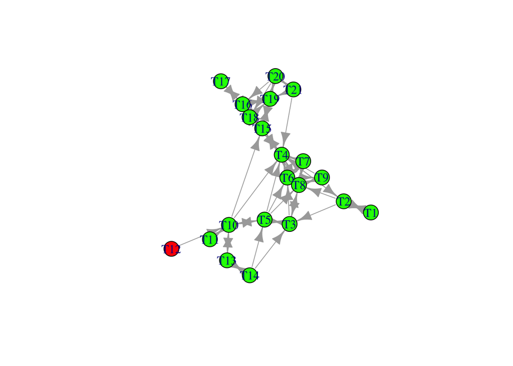

```r
plot(G)
```

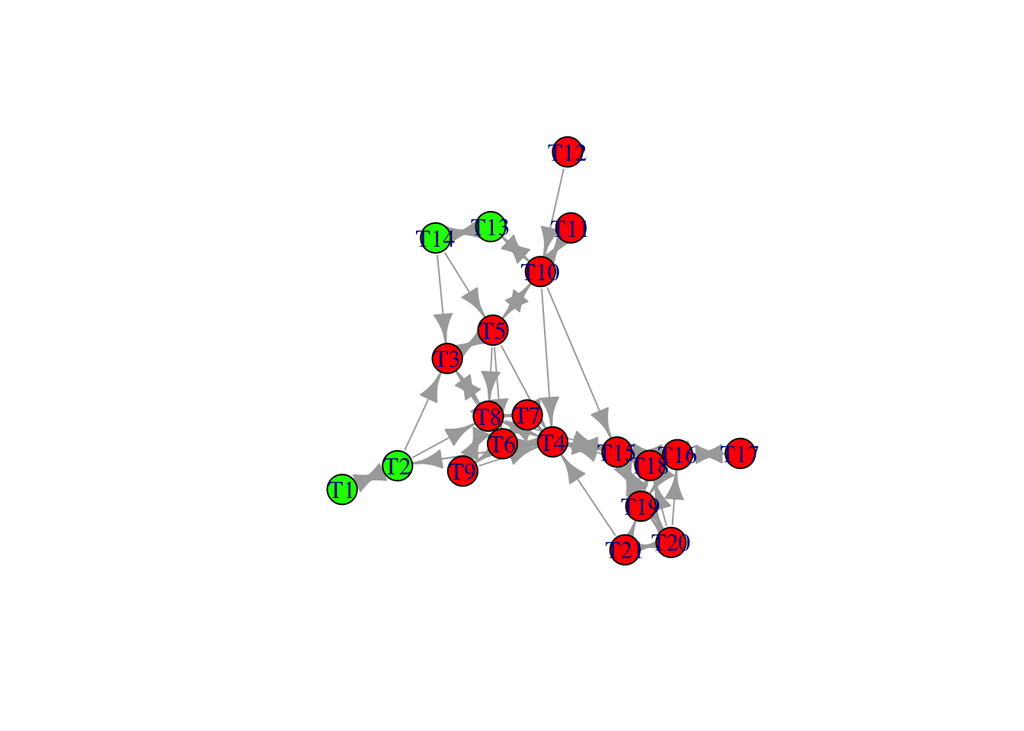

```r
plot(NG)
```

### Exercise 13:

Simulate 1000 trials of this Blood Parasite using random vaccination (i.e., randomly select a new set of three tuatara for each trial) and produce a plot of the average number of infected tuatara over time.

```r
count <- c()
for( i in 1:100)
{
list <- c(1:21)
random1 <- sample(x=list, size =1)
list1 <- list[list != random1]
random2 <- sample(x=list1, size = 1)
list2 <- list1[list1 != random2]
random3 <- sample(x=list2, size = 1)
list3 <- list2[list2 != random3]
count[i] <- mean(bPG(random1, random2, random3) )
}
mean(count)
```

```
## [1] 13.999
```

```r
sd(count)
```

```
## [1] 3.99263
```

### Exercise 14:

Discuss any patterns you observe in exercise (13).

### Exercise 15:

Discuss what effect random vaccination has on preventing the spread of blood parasites through a population when compared against no vaccination. Justify your answer numerically.

### Exercise 16:

Simulate 1000 trials of this Blood Parasite by vaccinating the three tuatara with the highest in-degree measures of centrality and produce a plot of the average number of infected tuatara over time.

```r
count <- (replicate(100,mean(bPG(4, 8, 15)) ))
mean(count)
```

```
## [1] 8.918
```

```r
sd(count)
```

```
## [1] 1.62498
```

### Exercise 17:

Simulate 1000 trials of this Blood Parasite by vaccinating the three tuatara with the highest out-degree measures of centrality and produce a plot of the average number of infected tuatara over time.

```r
count <- (replicate(100,mean(bPG(15, 20, 5)) ))
mean(count)
```

```
## [1] 12.6862
```

```r
sd(count)
```

```
## [1] 0.3961603
```

### Exercise 18:

Discuss whether random or targeted vaccination is more effective at preventing the spread of blood parasites through a population. Justify your answer numerically.

### Exercise 19:

Simulate 1000 trials of this Blood Parasite by vaccinating the three tuatara with the highest betweenness measures of centrality and produce a plot of the average number of infected tuatara over time.

```r
count <- (replicate(100,mean(bPG(12, 14, 10)) ))
mean(count)
```

```
## [1] 11.7546
```

```r
sd(count)
```

```
## [1] 7.21483
```

### Exercise 20:

Simulate 1000 trials of this Blood Parasite by vaccinating the three tuatara with the highest closeness measures of centrality and produce a plot of the average number of infected tuatara over time.

```r
count <- (replicate(100,mean(bPG(2, 3, 10)) ))
mean(count)
```

```
## [1] 14.3536
```

```r
sd(count)
```

```
## [1] 1.456149
```

### Exercise 21:

Simulate 1000 trials of this Blood Parasite by vaccinating the three tuatara with the highest eigenvector measures of centrality and produce a plot of the average number of infected tuatara over time.

```r
count <- (replicate(100,mean(bPG(15, 20, 5)) ))
mean(count)
```

```
## [1] 12.622
```

```r
sd(count)
```

```
## [1] 0.4854946
```

### Exercise 22:

Discuss which measure of centrality best captures the importance of different tuatara’s role in the spread of blood parasites through the population. Justify your answer numerically.

### Exercise 23:

Simulate 1000 trials of this Blood Parasite by vaccinating the three tuatara that serve as articulation points within the network and produce a plot of the average number of infected tuatara over time.

```r
ount <- (replicate(100,mean(bPG(16, 10, 2)) ))
mean(count)
```

```
## [1] 12.622
```

```r
sd(count)
```

```
## [1] 0.4854946
```

### Exercise 24:

Discuss how targeting articulation points compares with targeting individuals based on their importance to the network in terms of controlling the spread of blood parasites through the population. Justify your answer numerically.